# Data_analysis_in_R_PhD_class_JanosSalamon

# Deleting item 14, then re-run analysis.

```r
library(tidyverse)

motiv2 <-
  work_data %>%
  as_tibble() %>%
  select(mwms_1, mwms_2, mwms_3, mwms_4, mwms_5, mwms_6, mwms_7,
         mwms_8, mwms_9, mwms_10, mwms_11, mwms_12, mwms_13, mwms_15,
         mwms_16, mwms_17, mwms_18, mwms_19)


pc4 <- principal(motiv2, nfactors = 5, rotate = "promax")
pc4
```

```
## Principal Components Analysis
## Call: principal(r = motiv2, nfactors = 5, rotate = "promax")
## Standardized loadings (pattern matrix) based upon correlation matrix
##           RC1   RC4   RC2   RC5   RC3   h2   u2 com
## mwms_1  -0.10 -0.15  0.89 -0.23 -0.09 0.67 0.33 1.2
## mwms_2   0.08  0.09  0.77  0.14 -0.14 0.60 0.40 1.2
## mwms_3   0.88 -0.01  0.02 -0.01 -0.01 0.78 0.22 1.0
## mwms_4   0.07  0.02 -0.08  0.94  0.00 0.81 0.19 1.0
## mwms_5   0.11  0.64  0.06 -0.09 -0.02 0.60 0.40 1.1
## mwms_6   0.14 -0.02 -0.08  0.12  0.78 0.59 0.41 1.1
## mwms_7  -0.01 -0.06  0.74 -0.04  0.18 0.66 0.34 1.1
## mwms_8   0.13  0.30  0.55  0.10 -0.09 0.53 0.47 1.8
## mwms_9   0.96 -0.03  0.01  0.01 -0.02 0.89 0.11 1.0
## mwms_10 -0.04 -0.06 -0.02  0.84  0.03 0.81 0.19 1.0
## mwms_11 -0.09  0.82 -0.07 -0.10  0.03 0.64 0.36 1.1
## mwms_12 -0.02 -0.02  0.09 -0.17  0.76 0.63 0.37 1.1
## mwms_13 -0.06 -0.11  0.49  0.15  0.34 0.53 0.47 2.2
## mwms_15  0.92  0.00 -0.06 -0.07  0.05 0.89 0.11 1.0
## mwms_16 -0.19 -0.03  0.00  0.73 -0.07 0.75 0.25 1.2
## mwms_17  0.03  0.90 -0.10  0.04  0.01 0.75 0.25 1.0
## mwms_18 -0.07  0.12 -0.10  0.01  0.81 0.62 0.38 1.1
## mwms_19 -0.09  0.78  0.06  0.04  0.06 0.57 0.43 1.1
##
##                        RC1  RC4  RC2  RC5  RC3
## SS loadings           2.72 2.66 2.50 2.40 2.04
## Proportion Var        0.15 0.15 0.14 0.13 0.11
## Cumulative Var        0.15 0.30 0.44 0.57 0.68
## Proportion Explained  0.22 0.22 0.20 0.19 0.17
## Cumulative Proportion 0.22 0.44 0.64 0.83 1.00
##
##  With component correlations of
##       RC1   RC4   RC2   RC5   RC3
## RC1  1.00  0.54  0.19 -0.59 -0.07
## RC4  0.54  1.00  0.35 -0.45  0.04
## RC2  0.19  0.35  1.00 -0.02  0.39
## RC5 -0.59 -0.45 -0.02  1.00  0.13
## RC3 -0.07  0.04  0.39  0.13  1.00
##
## Mean item complexity =  1.2
## Test of the hypothesis that 5 components are sufficient.
##
## The root mean square of the residuals (RMSR) is  0.05
##  with the empirical chi square  640.27  with prob <  1.5e-91
##
## Fit based upon off diagonal values = 0.97
```

```r
print.psych(pc4, cut = 0.3, sort = TRUE)
```

```
## Principal Components Analysis
## Call: principal(r = motiv2, nfactors = 5, rotate = "promax")
## Standardized loadings (pattern matrix) based upon correlation matrix
##         item   RC1   RC4   RC2   RC5   RC3   h2   u2 com
## mwms_9     9  0.96                         0.89 0.11 1.0
## mwms_15   14  0.92                         0.89 0.11 1.0
## mwms_3     3  0.88                         0.78 0.22 1.0
## mwms_17   16        0.90                   0.75 0.25 1.0
## mwms_11   11        0.82                   0.64 0.36 1.1
## mwms_19   18        0.78                   0.57 0.43 1.1
## mwms_5     5        0.64                   0.60 0.40 1.1
## mwms_1     1              0.89             0.67 0.33 1.2
## mwms_2     2              0.77             0.60 0.40 1.2
## mwms_7     7              0.74             0.66 0.34 1.1
## mwms_8     8        0.30  0.55             0.53 0.47 1.8
## mwms_13   13              0.49        0.34 0.53 0.47 2.2
## mwms_4     4                    0.94       0.81 0.19 1.0
## mwms_10   10                    0.84       0.81 0.19 1.0
## mwms_16   15                    0.73       0.75 0.25 1.2
## mwms_18   17                          0.81 0.62 0.38 1.1
## mwms_6     6                          0.78 0.59 0.41 1.1
## mwms_12   12                          0.76 0.63 0.37 1.1
##
##                        RC1  RC4  RC2  RC5  RC3
## SS loadings           2.72 2.66 2.50 2.40 2.04
## Proportion Var        0.15 0.15 0.14 0.13 0.11
## Cumulative Var        0.15 0.30 0.44 0.57 0.68
## Proportion Explained  0.22 0.22 0.20 0.19 0.17
## Cumulative Proportion 0.22 0.44 0.64 0.83 1.00
##
##  With component correlations of
##       RC1   RC4   RC2   RC5   RC3
## RC1  1.00  0.54  0.19 -0.59 -0.07
## RC4  0.54  1.00  0.35 -0.45  0.04
## RC2  0.19  0.35  1.00 -0.02  0.39
## RC5 -0.59 -0.45 -0.02  1.00  0.13
## RC3 -0.07  0.04  0.39  0.13  1.00
##
## Mean item complexity =  1.2
## Test of the hypothesis that 5 components are sufficient.
##
## The root mean square of the residuals (RMSR) is  0.05
##  with the empirical chi square  640.27  with prob <  1.5e-91
##
## Fit based upon off diagonal values = 0.97
```

Pattern matrix shows high cross-loadings of item 13.

# Deleting item 13, then re-run analysis.

```r
motiv3 <-
  work_data %>%
  as_tibble() %>%
  select(mwms_1, mwms_2, mwms_3, mwms_4, mwms_5, mwms_6, mwms_7,
         mwms_8, mwms_9, mwms_10, mwms_11, mwms_12, mwms_15,
         mwms_16, mwms_17, mwms_18, mwms_19)

pc5 <- principal(motiv3, nfactors = 5, rotate = "promax")
pc5
```

```
## Principal Components Analysis
## Call: principal(r = motiv3, nfactors = 5, rotate = "promax")
## Standardized loadings (pattern matrix) based upon correlation matrix
##           RC1   RC4   RC2   RC5   RC3   h2   u2 com
## mwms_1  -0.11 -0.17  0.89 -0.20 -0.04 0.68 0.32 1.2
## mwms_2   0.07  0.06  0.78  0.16 -0.09 0.62 0.38 1.1
## mwms_3   0.87 -0.01  0.02 -0.02  0.00 0.78 0.22 1.0
## mwms_4   0.06  0.01 -0.06  0.93  0.02 0.81 0.19 1.0
## mwms_5   0.11  0.64  0.05 -0.09 -0.03 0.60 0.40 1.1
## mwms_6   0.14 -0.06 -0.02  0.14  0.79 0.63 0.37 1.1
## mwms_7  -0.03 -0.07  0.73 -0.01  0.22 0.65 0.35 1.2
## mwms_8   0.13  0.28  0.57  0.11 -0.05 0.55 0.45 1.7
## mwms_9   0.96 -0.02  0.01  0.01 -0.02 0.89 0.11 1.0
## mwms_10 -0.04 -0.06  0.00  0.84  0.04 0.81 0.19 1.0
## mwms_11 -0.08  0.81 -0.07 -0.11  0.01 0.64 0.36 1.1
## mwms_12 -0.03 -0.04  0.12 -0.14  0.76 0.65 0.35 1.1
## mwms_15  0.91  0.01 -0.07 -0.07  0.04 0.89 0.11 1.0
## mwms_16 -0.19 -0.04  0.02  0.73 -0.05 0.76 0.24 1.2
## mwms_17  0.04  0.89 -0.10  0.03 -0.01 0.75 0.25 1.0
## mwms_18 -0.09  0.12 -0.09  0.03  0.79 0.61 0.39 1.1
## mwms_19 -0.10  0.79  0.05  0.04  0.05 0.57 0.43 1.1
##
##                        RC1  RC4  RC2  RC5  RC3
## SS loadings           2.71 2.63 2.28 2.36 1.91
## Proportion Var        0.16 0.15 0.13 0.14 0.11
## Cumulative Var        0.16 0.31 0.45 0.59 0.70
## Proportion Explained  0.23 0.22 0.19 0.20 0.16
## Cumulative Proportion 0.23 0.45 0.64 0.84 1.00
##
##  With component correlations of
##       RC1   RC4   RC2   RC5   RC3
## RC1  1.00  0.53  0.24 -0.58 -0.04
## RC4  0.53  1.00  0.39 -0.44  0.07
## RC2  0.24  0.39  1.00 -0.11  0.33
## RC5 -0.58 -0.44 -0.11  1.00  0.06
## RC3 -0.04  0.07  0.33  0.06  1.00
##
## Mean item complexity =  1.1
## Test of the hypothesis that 5 components are sufficient.
##
## The root mean square of the residuals (RMSR) is  0.05
##  with the empirical chi square  583.85  with prob <  2e-86
##
## Fit based upon off diagonal values = 0.97
```

```r
print.psych(pc5, cut = 0.3, sort = TRUE)
```

```
## Principal Components Analysis
## Call: principal(r = motiv3, nfactors = 5, rotate = "promax")
## Standardized loadings (pattern matrix) based upon correlation matrix
##         item   RC1   RC4   RC2   RC5   RC3   h2   u2 com
## mwms_9     9  0.96                         0.89 0.11 1.0
## mwms_15   13  0.91                         0.89 0.11 1.0
## mwms_3     3  0.87                         0.78 0.22 1.0
## mwms_17   15        0.89                   0.75 0.25 1.0
## mwms_11   11        0.81                   0.64 0.36 1.1
## mwms_19   17        0.79                   0.57 0.43 1.1
## mwms_5     5        0.64                   0.60 0.40 1.1
## mwms_1     1              0.89             0.68 0.32 1.2
## mwms_2     2              0.78             0.62 0.38 1.1
## mwms_7     7              0.73             0.65 0.35 1.2
## mwms_8     8              0.57             0.55 0.45 1.7
## mwms_4     4                    0.93       0.81 0.19 1.0
## mwms_10   10                    0.84       0.81 0.19 1.0
## mwms_16   14                    0.73       0.76 0.24 1.2
## mwms_6     6                          0.79 0.63 0.37 1.1
## mwms_18   16                          0.79 0.61 0.39 1.1
## mwms_12   12                          0.76 0.65 0.35 1.1
##
##                        RC1  RC4  RC2  RC5  RC3
## SS loadings           2.71 2.63 2.28 2.36 1.91
## Proportion Var        0.16 0.15 0.13 0.14 0.11
## Cumulative Var        0.16 0.31 0.45 0.59 0.70
## Proportion Explained  0.23 0.22 0.19 0.20 0.16
## Cumulative Proportion 0.23 0.45 0.64 0.84 1.00
##
##  With component correlations of
##       RC1   RC4   RC2   RC5   RC3
## RC1  1.00  0.53  0.24 -0.58 -0.04
## RC4  0.53  1.00  0.39 -0.44  0.07
## RC2  0.24  0.39  1.00 -0.11  0.33
## RC5 -0.58 -0.44 -0.11  1.00  0.06
## RC3 -0.04  0.07  0.33  0.06  1.00
##
## Mean item complexity =  1.1
## Test of the hypothesis that 5 components are sufficient.
##
## The root mean square of the residuals (RMSR) is  0.05
##  with the empirical chi square  583.85  with prob <  2e-86
##
## Fit based upon off diagonal values = 0.97
```

Pattern matrix shows very clear loadings. Factors are theoretically appropriate.

# Variables are loading to the following factors. Each show a meaningful factor:

factor 1: Intinsic motivation (Intrin): mwms_3 + mwms_9 + mwms_15

factor 2: Autonomous extrinsic (Aut_Ext): mwms_5 + mwms_11 + mwms_17 + mwms_19

factor 3: Amotivation (Amotiv): mwms_4 + mwms_10 + mwms_16

fcator 4: Controlled extrinsic (Cont_Ext): mwms_1 + mwms_2 + mwms_7 + mwms_8

factor 5: External material (Ext_Mat): mwms_6 + mwms_12 + mwms_18

## 3. CFA model for new work motivation factors

```r
library(lavaan)

work_motiv <- '
Intrin =~ mwms_3 + mwms_9 + mwms_15
Aut_Ext =~ mwms_5 + mwms_11 + mwms_17 + mwms_19
Amotiv =~ mwms_4 + mwms_10 + mwms_16
Cont_Ext =~ mwms_1 + mwms_2 + mwms_7 + mwms_8
Ext_Mat =~ mwms_6 + mwms_12 + mwms_18'

fit_work_motiv <- cfa(work_motiv, data = work_data, estimator = 'MLR')
summary(fit_work_motiv, fit.measures = TRUE, standardized = TRUE)
```

```
## lavaan (0.6-1) converged normally after  52 iterations
##
##   Number of observations                           721
##
##   Estimator                                         ML      Robust
##   Model Fit Test Statistic                     442.242     362.554
##   Degrees of freedom                               109         109
##   P-value (Chi-square)                           0.000       0.000
##   Scaling correction factor                                  1.220
##     for the Yuan-Bentler correction (Mplus variant)
##
## Model test baseline model:
##
##   Minimum Function Test Statistic             6070.495    4456.689
##   Degrees of freedom                               136         136
##   P-value                                        0.000       0.000
##
## User model versus baseline model:
##
##   Comparative Fit Index (CFI)                    0.944       0.941
##   Tucker-Lewis Index (TLI)                       0.930       0.927
##
##   Robust Comparative Fit Index (CFI)                            NA
##   Robust Tucker-Lewis Index (TLI)                               NA
##
## Loglikelihood and Information Criteria:
##
##   Loglikelihood user model (H0)             -19779.156  -19779.156
##   Loglikelihood unrestricted model (H1)     -19558.035  -19558.035
##
##   Number of free parameters                         44          44
##   Akaike (AIC)                               39646.311   39646.311
##   Bayesian (BIC)                             39847.859   39847.859
##   Sample-size adjusted Bayesian (BIC)        39708.147   39708.147
##
## Root Mean Square Error of Approximation:
##
##   RMSEA                                          0.065       0.057
##   90 Percent Confidence Interval          0.059  0.072       0.051  0.063
##   P-value RMSEA <= 0.05                          0.000       0.027
```

[output cut: 65 more lines]

```
##    .mwms_4            0.676    0.089    7.637    0.000    0.676    0.376
##    .mwms_10           0.429    0.091    4.697    0.000    0.429    0.240
##    .mwms_16           0.502    0.066    7.590    0.000    0.502    0.305
##    .mwms_1            1.720    0.145   11.828    0.000    1.720    0.567
##    .mwms_2            1.791    0.141   12.704    0.000    1.791    0.571
##    .mwms_7            1.529    0.141   10.872    0.000    1.529    0.488
##    .mwms_8            1.259    0.115   10.980    0.000    1.259    0.616
##    .mwms_6            1.963    0.157   12.537    0.000    1.963    0.595
##    .mwms_12           1.456    0.172    8.445    0.000    1.456    0.480
##    .mwms_18           1.981    0.158   12.555    0.000    1.981    0.638
##     Intrin            1.460    0.147    9.954    0.000    1.000    1.000
##     Aut_Ext           0.842    0.100    8.401    0.000    1.000    1.000
##     Amotiv            1.124    0.139    8.061    0.000    1.000    1.000
##     Cont_Ext          1.315    0.164    8.015    0.000    1.000    1.000
##     Ext_Mat           1.335    0.171    7.809    0.000    1.000    1.000
```

Fit indices of the hypothesized representation of the constructs are satisfactory now (CFI = .941, TLI = .927, RMSEA = .057 [90% CI = .051-.063]).

## 4. Normality

Identifing violations of normality

# Loading packages

```r
library(dplyr)
library(MVN)
```

# variable calculation for work motivation factors

```r
motiv_variables <-
  work_data %>%
  mutate(Intrin_avg = mean(mwms_3, mwms_9, mwms_15, trim = 0, na.rm=TRUE),
         Aut_Ext_avg = mean(mwms_5, mwms_11, mwms_17, trim = 0, mwms_19, na.rm=TRUE),
         Amotiv_avg = mean(mwms_4, mwms_10, mwms_16, trim = 0, na.rm=TRUE),
         Cont_Ext_avg = mean(mwms_1, mwms_2, mwms_7, trim = 0, mwms_8, na.rm=TRUE),
         Ext_Mat_avg = mean(mwms_6, mwms_12, mwms_18, trim = 0, na.rm=TRUE))
```

# assessment of univariate and multivariate normality with Mardia’s test - work motivation

```r
avg_only_motiv <- motiv_variables %>%
  select(mwms_1, mwms_2, mwms_3, mwms_4, mwms_5, mwms_6, mwms_7, mwms_8, mwms_9,
         mwms_10, mwms_11, mwms_12, mwms_15, mwms_16, mwms_17, mwms_18, mwms_19)

mvn(avg_only_motiv)
```

```
## $multivariateNormality
##              Test        Statistic p value Result
## 1 Mardia Skewness 4744.13572991455       0     NO
## 2 Mardia Kurtosis 58.6848107535662       0     NO
## 3             MVN             <NA>    <NA>     NO
##
## $univariateNormality
##            Test  Variable Statistic   p value Normality
## 1  Shapiro-Wilk  mwms_1      0.9100  <0.001      NO
## 2  Shapiro-Wilk  mwms_2      0.8668  <0.001      NO
## 3  Shapiro-Wilk  mwms_3      0.8357  <0.001      NO
## 4  Shapiro-Wilk  mwms_4      0.7084  <0.001      NO
## 5  Shapiro-Wilk  mwms_5      0.8509  <0.001      NO
## 6  Shapiro-Wilk  mwms_6      0.9295  <0.001      NO
## 7  Shapiro-Wilk  mwms_7      0.9301  <0.001      NO
## 8  Shapiro-Wilk  mwms_8      0.8456  <0.001      NO
## 9  Shapiro-Wilk  mwms_9      0.8781  <0.001      NO
## 10 Shapiro-Wilk  mwms_10     0.7377  <0.001      NO
## 11 Shapiro-Wilk  mwms_11     0.8333  <0.001      NO
## 12 Shapiro-Wilk  mwms_12     0.9245  <0.001      NO
## 13 Shapiro-Wilk  mwms_15     0.8547  <0.001      NO
## 14 Shapiro-Wilk  mwms_16     0.6536  <0.001      NO
## 15 Shapiro-Wilk  mwms_17     0.8579  <0.001      NO
## 16 Shapiro-Wilk  mwms_18     0.9355  <0.001      NO
## 17 Shapiro-Wilk  mwms_19     0.8550  <0.001      NO
##
## $Descriptives
##           n     Mean  Std.Dev Median Min Max 25th 75th        Skew
## mwms_1  721 4.590846 1.743360      5   1   7    4    6 -0.57680408
## mwms_2  721 5.001387 1.771298      6   1   7    4    6 -0.87059414
## mwms_3  721 5.502080 1.513021      6   1   7    5    7 -1.22208702
## mwms_4  721 1.901526 1.342680      1   1   7    1    2  1.69212631
## mwms_5  721 5.578363 1.259311      6   1   7    5    6 -1.20817064
## mwms_6  721 3.764216 1.817323      4   1   7    2    5  0.02853244
## mwms_7  721 3.787795 1.771116      4   1   7    2    5 -0.08495258
## mwms_8  721 5.381415 1.430866      6   1   7    5    6 -1.21852490
## mwms_9  721 5.092926 1.650242      6   1   7    4    6 -0.89999441
## mwms_10 721 1.970874 1.337695      1   1   7    1    2  1.62445858
## mwms_11 721 5.703190 1.286944      6   1   7    5    7 -1.27885050
## mwms_12 721 4.105409 1.743236      4   1   7    3    5 -0.32484704
```

[output cut: 8 more lines]

```
## mwms_3   1.03879310
## mwms_4   2.44562213
## mwms_5   1.66514567
## mwms_6  -1.12025008
## mwms_7  -1.08211605
## mwms_8   1.19809746
## mwms_9   0.03810702
## mwms_10  2.31259029
## mwms_11  1.69154761
## mwms_12 -0.94823312
## mwms_15  0.36227279
## mwms_16  4.69491359
## mwms_17  1.38590821
## mwms_18 -1.02585167
## mwms_19  0.64850792
```

# Filtering missing values from burnout data

```r
work_data2 <- work_data %>%
  filter(!is.na(burn_1),
         !is.na(burn_2),
         !is.na(burn_3),
         !is.na(burn_4),
         !is.na(burn_5),
         !is.na(burn_6),
         !is.na(burn_7),
         !is.na(burn_8),
         !is.na(burn_9),
         !is.na(burn_10),
         !is.na(burn_11),
         !is.na(burn_12),
         !is.na(burn_13),
         !is.na(burn_14))
```

# variable calculation for burnout factors

```r
burnout_variables <-
  work_data2 %>%
  mutate(Physical_B_avg = mean(burn_1, burn_3, burn_5, burn_8, burn_10, burn_12, trim = 0, na.rm=TRUE),
         Cognitive_B_avg = mean(burn_2, burn_6, burn_9, burn_11, burn_13, trim = 0, na.rm=TRUE),
         Emotional_B_avg = mean(burn_4, burn_7, burn_14, trim = 0, na.rm=TRUE))
```

# assessment of univariate and multivariate normality with Mardia’s test - burnout

```r
avg_only_burn <- burnout_variables %>%
  select(burn_1, burn_2, burn_3, burn_4, burn_5, burn_6, burn_7, burn_8, burn_9, burn_10,
         burn_11, burn_12, burn_13, burn_14)

mvn(avg_only_burn)
```

```
## $multivariateNormality
##              Test        Statistic               p value Result
## 1 Mardia Skewness 1778.58933569758 8.98935327777942e-127     NO
## 2 Mardia Kurtosis 28.4383325893336                     0     NO
## 3             MVN             <NA>                  <NA>     NO
##
## $univariateNormality
##            Test  Variable Statistic   p value Normality
## 1  Shapiro-Wilk  burn_1      0.9300  <0.001      NO
## 2  Shapiro-Wilk  burn_2      0.9166  <0.001      NO
## 3  Shapiro-Wilk  burn_3      0.9235  <0.001      NO
## 4  Shapiro-Wilk  burn_4      0.8958  <0.001      NO
## 5  Shapiro-Wilk  burn_5      0.9395  <0.001      NO
## 6  Shapiro-Wilk  burn_6      0.9212  <0.001      NO
## 7  Shapiro-Wilk  burn_7      0.8908  <0.001      NO
## 8  Shapiro-Wilk  burn_8      0.8999  <0.001      NO
## 9  Shapiro-Wilk  burn_9      0.8527  <0.001      NO
## 10 Shapiro-Wilk  burn_10     0.9155  <0.001      NO
## 11 Shapiro-Wilk  burn_11     0.8937  <0.001      NO
## 12 Shapiro-Wilk  burn_12     0.8416  <0.001      NO
## 13 Shapiro-Wilk  burn_13     0.8805  <0.001      NO
## 14 Shapiro-Wilk  burn_14     0.8246  <0.001      NO
##
## $Descriptives
##           n     Mean  Std.Dev Median Min Max 25th 75th       Skew
## burn_1  652 4.328221 1.307993      4   1   7    4    5 -0.2013205
## burn_2  652 3.032209 1.235872      3   1   7    2    4  0.2461120
## burn_3  652 3.322086 1.565940      3   1   7    2    4  0.4895728
## burn_4  652 2.728528 1.285001      2   1   7    2    4  0.6617607
## burn_5  652 3.562883 1.490586      4   1   7    2    5  0.2548108
## burn_6  652 3.170245 1.233246      3   1   7    2    4  0.3271702
## burn_7  652 2.774540 1.376708      2   1   7    2    4  0.8000072
## burn_8  652 3.049080 1.605688      3   1   7    2    4  0.6449354
## burn_9  652 2.323620 1.263159      2   1   7    1    3  0.9515828
## burn_10 652 3.150307 1.582969      3   1   7    2    4  0.5437338
## burn_11 652 2.848160 1.319805      2   1   7    2    4  0.6283403
## burn_12 652 2.535276 1.617012      2   1   7    1    4  0.9923436
## burn_13 652 2.607362 1.313691      2   1   7    2    4  0.7771962
## burn_14 652 2.256135 1.279776      2   1   7    1    3  1.2488794
##            Kurtosis
## burn_1  -0.15669462
## burn_2  -0.49001876
## burn_3  -0.50336715
## burn_4  -0.01286567
## burn_5  -0.62540443
## burn_6  -0.31074792
## burn_7   0.16308258
## burn_8  -0.39319056
## burn_9   0.52339773
## burn_10 -0.52238954
## burn_11 -0.23809163
## burn_12  0.08238524
## burn_13  0.12358833
## burn_14  1.39449283
```

# Filtering missing values from satisfaction data

```r
work_data3 <- work_data %>%
  filter(!is.na(swws_1),
         !is.na(swws_2),
         !is.na(swws_3),
         !is.na(swws_4),
         !is.na(swws_5))
```

# variable calculation for work satisfaction factor

```r
sat_variables <-
  work_data3 %>%
  mutate(satis_avg = mean(swws_1, swws_2, swws_3, swws_4, swws_5, trim = 0, na.rm=T))
```

# assessment of univariate and multivariate normality with Mardia’s test - work satisfation

```r
avg_only_sat <- sat_variables %>%
  select(swws_1:swws_5)

mvn(avg_only_sat)
```

```
## $multivariateNormality
##              Test        Statistic              p value Result
## 1 Mardia Skewness 257.839990587922 9.06383887874747e-36     NO
## 2 Mardia Kurtosis  9.7377351379834                    0     NO
## 3             MVN             <NA>                 <NA>     NO
##
## $univariateNormality
##           Test  Variable Statistic   p value Normality
## 1 Shapiro-Wilk  swws_1      0.9238  <0.001      NO
## 2 Shapiro-Wilk  swws_2      0.9219  <0.001      NO
## 3 Shapiro-Wilk  swws_3      0.8849  <0.001      NO
## 4 Shapiro-Wilk  swws_4      0.9292  <0.001      NO
## 5 Shapiro-Wilk  swws_5      0.9175  <0.001      NO
##
## $Descriptives
##          n     Mean  Std.Dev Median Min Max 25th 75th       Skew
## swws_1 656 4.463415 1.621008      5   1   7    4    6 -0.4981956
## swws_2 656 4.653963 1.588340      5   1   7    4    6 -0.5373061
## swws_3 656 4.989329 1.448835      5   1   7    4    6 -0.9287767
## swws_4 656 4.390244 1.628045      5   1   7    3    6 -0.4081910
## swws_5 656 4.347561 1.892837      4   1   7    3    6 -0.3080520
##          Kurtosis
## swws_1 -0.5841474
## swws_2 -0.4718759
## swws_3  0.4079996
## swws_4 -0.7298697
## swws_5 -1.0357385
```

Results indicate the violance of normality.

## 5. Final SEM MODEL

Using structural equation modelling for modeling the connection between burnout, work motivation and work satisfaction factors with satisfactory fit indices.

# Loading package

```r
library(lavaan)
```

# Final model

```r
my_model2 <- '
  # measurement model
burnout =~ Physical_B + Emotional_B + Cognitive_B
Physical_B =~ burn_1 + burn_3 + burn_5 + burn_8 + burn_10 + burn_12
Cognitive_B =~ burn_2 + burn_6 + burn_9 + burn_11 + burn_13
Emotional_B =~ burn_4 + burn_7 + burn_14

Intrin =~ mwms_3 + mwms_9 + mwms_15
Aut_Ext =~ mwms_5 + mwms_11 + mwms_17 + mwms_19
Amotiv =~ mwms_4 + mwms_10 + mwms_16
Cont_Ext =~ mwms_1 + mwms_2 + mwms_7 + mwms_8
Ext_Mat =~ mwms_6 + mwms_12 + mwms_18

work_satisf =~ swws_1 + swws_2 + swws_3 + swws_4 + swws_5
            swws_2 ~~ swws_5

# regressions
burnout ~ Amotiv + Ext_Mat + Cont_Ext + Aut_Ext + Intrin
work_satisf ~ Amotiv + Ext_Mat + Cont_Ext + Aut_Ext + Intrin
burnout ~~ work_satisf'
```

# model fit and summary of model fit

```r
my_model_fit2 <- cfa(my_model2, data = work_data, estimator = 'MLR')
summary(my_model_fit2, fit.measures=TRUE, standardized = TRUE)
```

```
## lavaan (0.6-1) converged normally after  58 iterations
##
##                                                   Used       Total
##   Number of observations                           622         721
##
##   Estimator                                         ML      Robust
##   Model Fit Test Statistic                    1778.829    1583.901
##   Degrees of freedom                               569         569
##   P-value (Chi-square)                           0.000       0.000
##   Scaling correction factor                                  1.123
##     for the Yuan-Bentler correction (Mplus variant)
##
## Model test baseline model:
##
##   Minimum Function Test Statistic            13932.522   11837.842
##   Degrees of freedom                               630         630
##   P-value                                        0.000       0.000
##
## User model versus baseline model:
##
##   Comparative Fit Index (CFI)                    0.909       0.909
##   Tucker-Lewis Index (TLI)                       0.899       0.900
##
##   Robust Comparative Fit Index (CFI)                            NA
##   Robust Tucker-Lewis Index (TLI)                               NA
##
## Loglikelihood and Information Criteria:
##
##   Loglikelihood user model (H0)             -34470.578  -34470.578
##   Loglikelihood unrestricted model (H1)     -33581.163  -33581.163
##
##   Number of free parameters                         97          97
##   Akaike (AIC)                               69135.155   69135.155
##   Bayesian (BIC)                             69565.151   69565.151
##   Sample-size adjusted Bayesian (BIC)        69257.191   69257.191
##
## Root Mean Square Error of Approximation:
##
##   RMSEA                                          0.058       0.054
##   90 Percent Confidence Interval          0.055  0.062       0.051  0.057
```

[output cut: 136 more lines]

```
##    .swws_1            0.582    0.053   10.951    0.000    0.582    0.218
##    .swws_2            1.477    0.108   13.686    0.000    1.477    0.581
##    .swws_3            0.463    0.050    9.281    0.000    0.463    0.217
##    .swws_4            1.539    0.109   14.073    0.000    1.539    0.579
##    .swws_5            1.382    0.110   12.543    0.000    1.382    0.385
##    .burnout           0.440    0.064    6.883    0.000    0.646    0.646
##     Physical_B        0.133    0.045    2.995    0.003    0.164    0.164
##     Cognitive_B       0.178    0.036    5.009    0.000    0.281    0.281
##     Emotional_B       0.374    0.064    5.854    0.000    0.436    0.436
##     Intrin            1.382    0.155    8.933    0.000    1.000    1.000
##     Aut_Ext           0.859    0.105    8.206    0.000    1.000    1.000
##     Amotiv            1.131    0.153    7.402    0.000    1.000    1.000
##     Cont_Ext          1.323    0.177    7.491    0.000    1.000    1.000
##     Ext_Mat           1.246    0.180    6.937    0.000    1.000    1.000
##    .work_satisf       0.855    0.084   10.212    0.000    0.410    0.410
```

Fit indices highlighted that the hypothesized representation of the constructs is satisfactory.

# Plotting the models with semPlot

```r
library(semPlot)
```

# Seeing the clean model structure

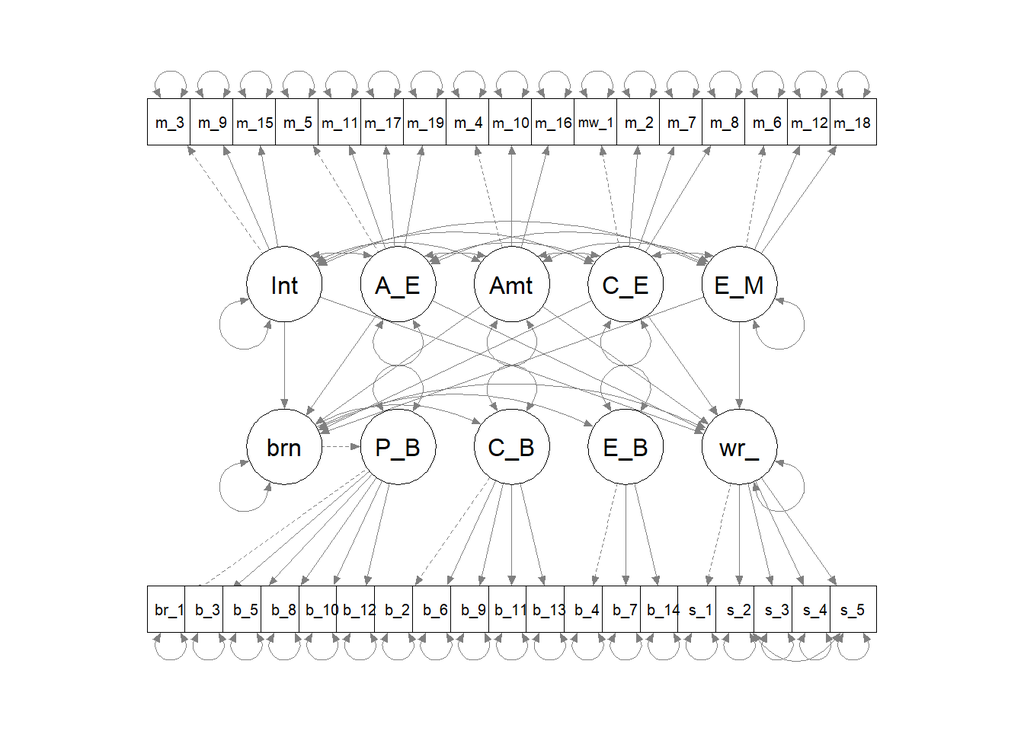

```r
semPaths(my_model_fit2)
```

# Getting standardized estimates

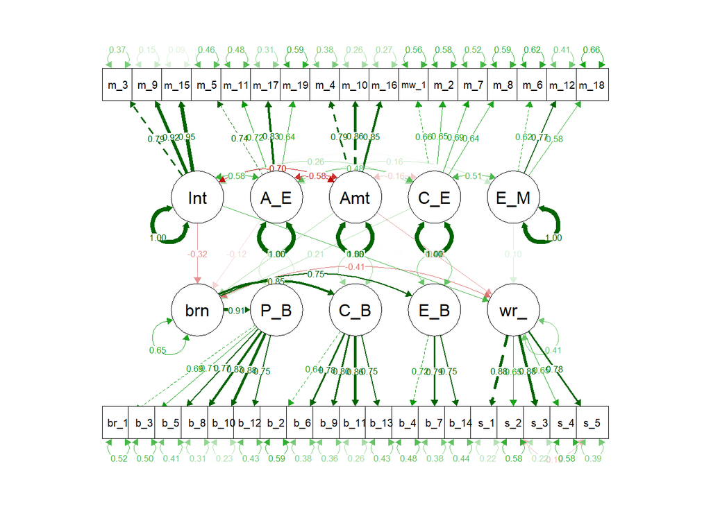

```r
semPaths(my_model_fit2, "std")
```

## 6. Results of final SEM Model

In the model the fit indices are acceptable (CFI = .909, TLI = .900, RMSEA = .054 [90% CI = .051-.057])

Both amotivation (beta = .27, p = .001) and controlled extrinsic motivation (beta = .215, p = .007) were related positively but weakly to burnout. Intrinsic motivation (beta = -.317, p < .001) has negative relation to burnout. However, neither external material based motivaton (beta = -.012, p = .855), nor autonomous extrinsic motivation (beta = -.119, p = .143) related significantly to burnout.

Intrinsic motivation is positively related to work satisfaction (beta = .529, p < .001), while amotivation has negative relation to that (beta = -.279, p < .001). External material based motivaton (beta = .103, p = .068), controlled extrinsic motivation (beta = .000, p = .998), and autonomous extrinsic motivation (beta = .012, p = .831) does not have any relation to work satisfaction.